# Лабораторная работа № 2. Простые сети в GNS3. Анализ трафика

Презентация

Глушенок А. А.

Российский университет дружбы народов, Москва, Россия

26 сентября 2026

## Докладчик

- Глушенок Анна Александровна
- Студент НПИбд-01-24
- Факультет физико-математических и естественных наук
- Российский университет дружбы народов
- 1132246844@pfur.ru
- https://github.com/aaglushenok

## Цель работы

Построение простейших моделей сети на базе коммутатора и маршрутизаторов FRR и VyOS в GNS3, анализ трафика посредством Wireshark.

## Задание

Для блока “Моделирование простейшей сети на базе коммутатора в GNS3”: 1. Построить в GNS3 топологию сети, состоящей из коммутатора Ethernet и двух оконечных устройств (персональных компьютеров). 2. Задать оконечным устройствам IP-адреса в сети 192.168.1.0/24. Проверить связь.

Для блока “Анализ трафика в GNS3 посредством Wireshark”: 1. С помощью Wireshark захватить и проанализировать ARP-сообщения. 2. С помощью Wireshark захватить и проанализировать ICMP-сообщения.

## Задание

Для блока “Моделирование простейшей сети на базе маршрутизатора FRR в GNS3”: 1. Построить в GNS3 топологию сети, состоящей из маршрутизатора FRR, коммутатора Ethernet и оконечного устройства. 2. Задать оконечному устройству IP-адрес в сети 192.168.1.0/24. 3. Присвоить интерфейсу маршрутизатора адрес 192.168.1.1/24 4. Проверить связь.

Для блока “Моделирование простейшей сети на базе маршрутизатора VyOS в GNS3”: 1. Построить в GNS3 топологию сети, состоящей из маршрутизатора VyOS, ком- мутатора Ethernet и оконечного устройства. 2. Задать оконечному устройству IP-адрес в сети 192.168.1.0/24. 3. Присвоить интерфейсу маршрутизатора адрес 192.168.1.1/24 4. Проверить связь.

# Выполнение лабораторной работы

# Моделирование простейшей сети на базе коммутатора в GNS3

## Моделирование простейшей сети на базе коммутатора в GNS3

1. Запустите GNS3 VM и GNS3. Создайте новый проект
2. В рабочей области GNS3 разместите коммутатор и два VPCS. Измените название устройств, включив имя учётной записи студента. Соедините VPCS с коммутатором. Отобразите обозначение интерфейсов соединения

[figure not shown]

Figure 1: размещение коммутатора и VPCS

## Моделирование простейшей сети на базе коммутатора в GNS3

[figure not shown]

Figure 2: изменение названий устройств

## Моделирование простейшей сети на базе коммутатора в GNS3

[figure not shown]

Figure 3: отображение интерфейсов соединения

## Моделирование простейшей сети на базе коммутатора в GNS3

3. Запустите Start, затем вызовите Console. Просмотрите синтаксис возможных команд. Задайте IP-адрес 192.168.1.11 в сети 192.168.1.0/24, для сохранения введите save. Аналогичным образом задайте IP-адрес 192.168.1.12 для PC-2

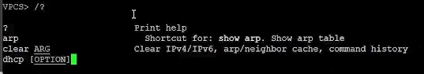

Figure 4: просмотр синтаксиса команд

## Моделирование простейшей сети на базе коммутатора в GNS3

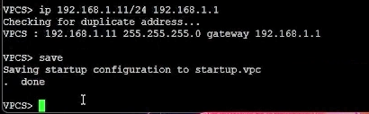

Figure 5: задание IP-адреса для РС-1

## Моделирование простейшей сети на базе коммутатора в GNS3

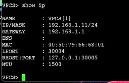

## Моделирование простейшей сети на базе коммутатора в GNS3

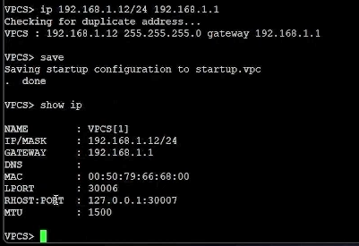

Figure 7: задание IP-адреса для РС-2

## Моделирование простейшей сети на базе коммутатора в GNS3

4. Проверьте работоспособность соединения между PC-1 и PC-2 с помощью команды ping
5. Остановите в проекте все узлы (меню GNS3 Control Stop all nodes )

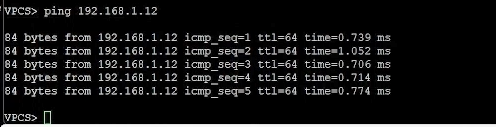

Figure 8: проверка соединения между PC-1 и PC-2

## Моделирование простейшей сети на базе коммутатора в GNS3

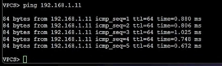

Figure 9: проверка соединения между PC-2 и PC-1

# Анализ трафика в GNS3 посредством Wireshark

## Анализ трафика в GNS3 посредством Wireshark

1. Запустите на соединении между PC-1 и коммутатором анализатор трафика. Запустится Wireshark, в проекте GNS3 на соединении появится значок лупы

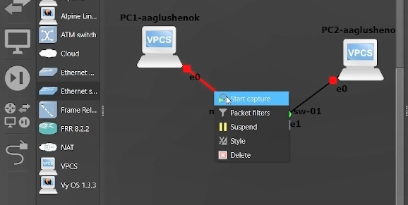

Figure 10: запуск анализа трафика

## Анализ трафика в GNS3 посредством Wireshark

[figure not shown]

Figure 11: проверка: появился значок лупы

## Анализ трафика в GNS3 посредством Wireshark

2. В проекте стартуйте все узлы. В окне Wireshark отобразится информация по протоколу ARP

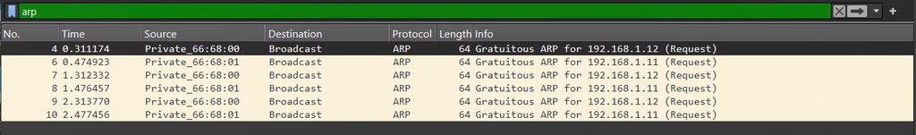

Figure 12: список ARP-запросов

## Анализ трафика в GNS3 посредством Wireshark

В окне WireShark Мы получили список ARP-запросов. Устройства рассылают Gratuitous ARP (широковещательные запросы), чтобы объявить свои IP-адреса и проверить их уникальность в сети. Это стандартное поведение при старте узлов.

## Анализ трафика в GNS3 посредством Wireshark

3. В терминале PC-2 посмотрите информацию по опциям команды ping, затем сделайте один эхо-запрос в ICMP-моде к узлу PC-1

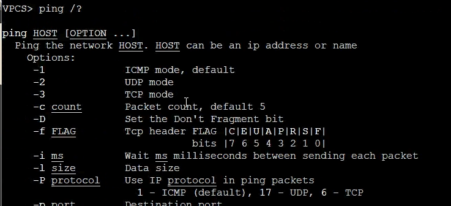

Figure 13: информация по опциям команды ping

## Анализ трафика в GNS3 посредством Wireshark

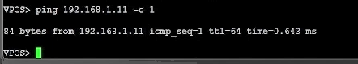

Figure 14: эхо-запрос в ICMP-моде к узлу PC-1

## Анализ трафика в GNS3 посредством Wireshark

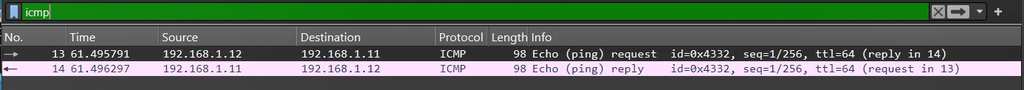

Figure 15: список ICMP-запросов

## Анализ трафика в GNS3 посредством Wireshark

В окне Wireshark мы видим обмен пакетами между PC-2 (192.168.1.12) и PC-1 (192.168.1.11). PC-2 отправляет Echo (ping) request (запрос), а PC-1 отвечает Echo (ping) reply (ответ). Это стандартный механизм проверки доступности узла в сети.

## Анализ трафика в GNS3 посредством Wireshark

4. Сделайте один эхо-запрос в UDP-моде к узлу PC-1

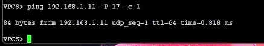

Figure 16: эхо-запрос в UDP-моде к узлу PC-1

## Анализ трафика в GNS3 посредством Wireshark

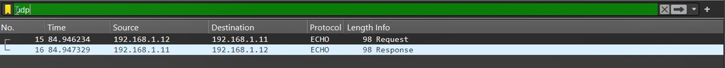

Figure 17: список UDP-запросов

## Анализ трафика в GNS3 посредством Wireshark

В окне Wireshark мы видим обмен пакетами между PC-2 (192.168.1.12) и PC-1 (192.168.1.11). PC-2 отправляет Request (запрос), а PC-1 отвечает Response (ответ). Это показывает передачу данных без установления соединения (UDP), в отличие от ICMP, где проверяется доступность.

## Анализ трафика в GNS3 посредством Wireshark

5. Сделайте один эхо-запрос в TCP-моде к узлу PC-1

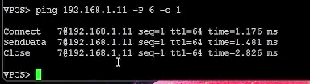

Figure 18: эхо-запрос в TCP-моде к узлу PC-1

## Анализ трафика в GNS3 посредством Wireshark

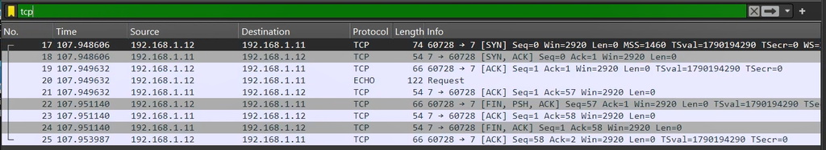

Figure 19: список TCP-запросов

## Анализ трафика в GNS3 посредством Wireshark

6. Остановите захват пакетов в Wireshark

[figure not shown]

Figure 20: остановка захвата пакетов

# Моделирование простейшей сети на базе маршрутизатора FRR в GNS3

## Моделирование простейшей сети на базе маршрутизатора FRR в GNS3

1. Запустите GNS3 VM и GNS3. Создайте новый проект
2. В рабочей области GNS3 разместите VPCS, коммутатор и маршрутизатор FRR
3. Измените отображаемые названия устройств
4. Включите захват трафика на соединении между коммутатором и маршрутизатором

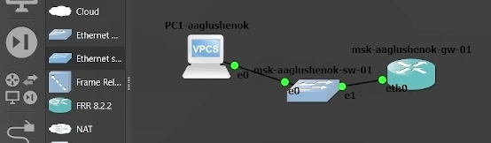

Figure 21: проект с маршрутизатором FRR

## Моделирование простейшей сети на базе маршрутизатора FRR в GNS3

5. Запустите все устройства проекта. Откройте консоль всех устройств проекта
6. Настройте IP-адресацию для интерфейса узла PC1

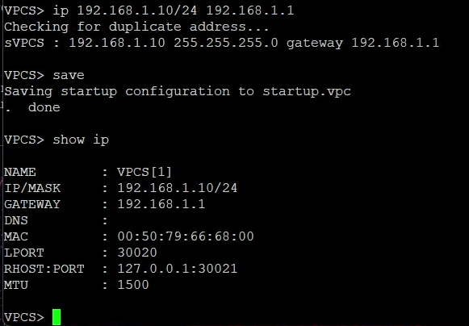

Figure 22: настройка IP-адресации для PC-1

## Моделирование простейшей сети на базе маршрутизатора FRR в GNS3

7. Настройте IP-адресацию для интерфейса локальной сети маршрутизатора

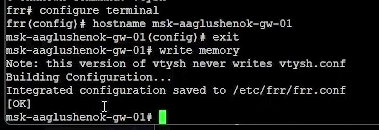

## Моделирование простейшей сети на базе маршрутизатора FRR в GNS3

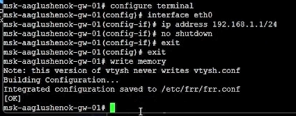

Figure 24: Настройка IP-адресации сети маршрутизатора

## Моделирование простейшей сети на базе маршрутизатора FRR в GNS3

8. Проверьте конфигурацию маршрутизатора и настройки IP-адресации

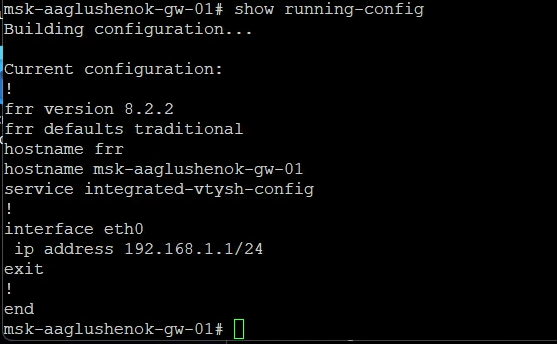

Figure 25: проверка конфигурации маршрутизатора

## Моделирование простейшей сети на базе маршрутизатора FRR в GNS3

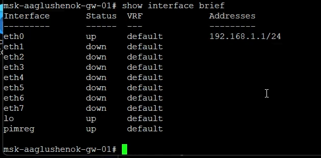

Figure 26: проверка настроек IP-адресации

## Моделирование простейшей сети на базе маршрутизатора FRR в GNS3

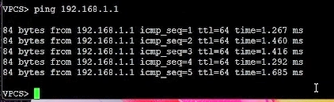

Figure 27: проверка подключения

## Моделирование простейшей сети на базе маршрутизатора FRR в GNS3

# Моделирование простейшей сети на базе маршрутизатора VyOS в GNS3

## Моделирование простейшей сети на базе маршрутизатора VyOS в GNS3

1. Запустите GNS3 VM и GNS3. Создайте новый проект
2. В рабочей области GNS3 разместите VPCS, коммутатор и маршрутизатор VyOS
3. Измените отображаемые названия устройств
4. Включите захват трафика на соединении между коммутатором и маршрутизатором

[figure not shown]

Figure 28: проект с маршрутизатором VyOS

## Моделирование простейшей сети на базе маршрутизатора VyOS в GNS3

5. Запустите все устройства проекта. Откройте консоль всех устройств проекта
6. Настройте IP-адресацию для интерфейса узла PC1

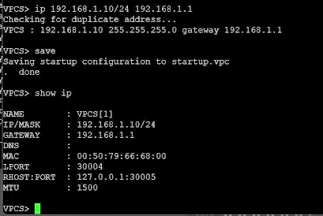

Figure 29: настройка IP-адресации для узла PC1

## Моделирование простейшей сети на базе маршрутизатора VyOS в GNS3

7. Настройте маршрутизатор VyOS. Изменения в имени устройства вступят в силу после применения и сохранения конфигурации и перезапуска устройства

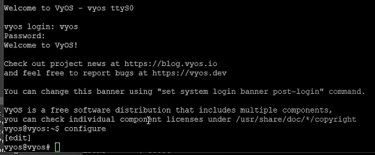

Figure 30: ввод логина, переход в режим конфигурирования

## Моделирование простейшей сети на базе маршрутизатора VyOS в GNS3

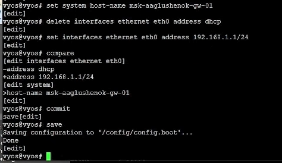

Figure 31: изменение имени, удаление указания, задание ip-адреса